# FraudDetect - Corrected Fraud Analytics Report

Author

Ludovic Njiosseu, MPH (Biostatistics)

Published

November 11, 2026

## Executive summary

This report documents the corrected FraudDetect analytical workflow using 10,000 simulated financial transactions. It compares supervised fraud classifiers, evaluates a training-only Isolation Forest with validation-derived alert thresholds, and explores investigation-cost scenarios.

**Scope limitation:** The data are simulated. Performance metrics are not evidence of performance on real financial institution transactions. Financial estimates use transaction amount as an exposure proxy and explicit illustrative assumptions. They are not realized losses, actual recoveries, or validated savings.

## Reproducibility and inputs

If `data/transactions.csv` does not exist, generate the simulated dataset first. Run the commands below from the repository root. The final, leakage-safe analysis outputs used in this report are produced by scripts 01, 04, and 05:

```r
source("scripts/01_simulate_data.R")
source("corrected_r/scripts/01_modeling.R")
source("corrected_r/scripts/04_optimize_anomaly_thresholds.R")
source("corrected_r/scripts/05_cost_sensitive_alert_optimization.R")
```

The report reads generated CSVs from `corrected_r/outputs/`. It does not rerun the original historical scripts.

## Corrected R script inventory

The `corrected_r/scripts/` directory contains five analytical scripts. They are not all part of the final production-style execution sequence because the later leakage-safe workflow supersedes parts of the earlier exploratory analysis.

| Script | Purpose | Role in the final workflow |
| --- | --- | --- |
| `01_modeling.R` | Creates the stratified train/validation/test split, fits Random Forest and XGBoost, selects thresholds on validation data, and evaluates once on the held-out test set. | Core: Run first. |
| `02_anomaly_detection.R` | Earlier standalone Isolation Forest anomaly-scoring analysis. | Exploratory predecessor: Its output is not used for the final leakage-safe policy results. |
| `03_anomaly_incremental_value.R` | Compares the earlier anomaly scores with XGBoost predictions to examine incremental alert value. | Exploratory predecessor: Do not use its results as the final leakage-safe comparison. |
| `04_optimize_anomaly_thresholds.R` | Refits Isolation Forest on training features only, derives alert thresholds from validation scores, and evaluates policies on the held-out test set. | Core: Supersedes the earlier thresholding approach in script 02. |
| `05_cost_sensitive_alert_optimization.R` | Compares alert policies under review-cost, recovery, and investigation-capacity assumptions. | Core: Run after scripts 01 and 04. |

`00_setup.R` is a package setup helper, not one of the five analytical scripts. It installs the packages required by the corrected analysis and dashboard.

For the headline results in this report, use the core sequence `01_modeling.R` → `04_optimize_anomaly_thresholds.R` → `05_cost_sensitive_alert_optimization.R`. Scripts 02 and 03 are retained for transparency and historical comparison, not as inputs to the final policy evaluation.

```r
library(tidyverse)
library(knitr)
out_dir <- "corrected_r/outputs"

model_metrics <- read_csv(file.path(out_dir, "model_comparison.csv"), show_col_types = FALSE)
policy_metrics <- read_csv(file.path(out_dir, "if_threshold_policy_comparison.csv"), show_col_types = FALSE)
cost_comparison <- read_csv(file.path(out_dir, "cost_sensitive_policy_comparison.csv"), show_col_types = FALSE)
cost_sensitivity <- read_csv(file.path(out_dir, "cost_sensitivity_analysis.csv"), show_col_types = FALSE)
investigation_capacity <- 500L
feasible_cost_comparison <- cost_comparison |> filter(alerts <= investigation_capacity)
feasible_cost_sensitivity <- cost_sensitivity |> filter(alerts <= investigation_capacity)
assumptions <- read_csv(file.path(out_dir, "cost_model_assumptions.csv"), show_col_types = FALSE)
importance <- read_csv(file.path(out_dir, "rf_variable_importance.csv"), show_col_types = FALSE)
```

## Data partition and evaluation design

The modeling script creates mutually exclusive stratified partitions:

| Partition | Share | Role |
| --- | --- | --- |
| Training | 60% | Fit supervised models and Isolation Forest |
| Validation | 20% | XGBoost early stopping and threshold selection |
| Test | 20% | Final held-out evaluation |

Classification thresholds are selected on validation data. Isolation Forest is fitted using training features only, without fraud labels. Anomaly-score thresholds are selected from validation-score quantiles and then evaluated on the held-out test set.

## Supervised model comparison

```r
model_metrics |>
  select(model, test_roc_auc, test_pr_auc, precision, recall, specificity,
         false_positives, false_negatives) |>
  kable(digits = 3, caption = "Held-out test performance")
```

Held-out test performance

| model | test_roc_auc | test_pr_auc | precision | recall | specificity | false_positives | false_negatives |
| --- | --- | --- | --- | --- | --- | --- | --- |
| Random_Forest | 0.694 | 0.165 | 0.124 | 0.571 | 0.697 | 564 | 60 |
| XGBoost | 0.752 | 0.211 | 0.161 | 0.564 | 0.778 | 412 | 61 |
| Equal_Weight_Blend | 0.745 | 0.190 | 0.157 | 0.550 | 0.777 | 414 | 63 |

XGBoost achieved the strongest ROC-AUC and PR-AUC among the three evaluated candidates in this run. At its validation-selected operating threshold, the test evaluation recorded 491 alerts, 79 true positives, and 412 false positives. This is a model comparison on synthetic data, not a production performance claim.

### ROC-AUC and PR-AUC

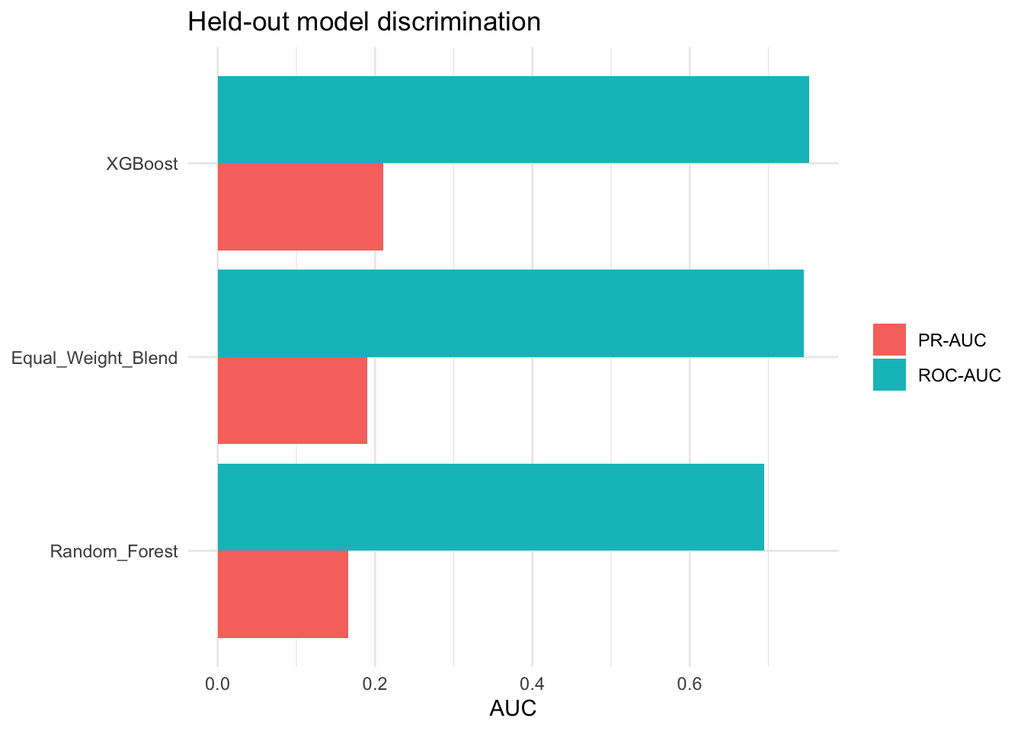

```r
model_metrics |>
  select(model, test_roc_auc, test_pr_auc) |>
  pivot_longer(-model, names_to = "metric", values_to = "value") |>
  mutate(metric = recode(metric,
                         test_roc_auc = "ROC-AUC",
                         test_pr_auc = "PR-AUC")) |>
  ggplot(aes(x = reorder(model, value), y = value, fill = metric)) +
  geom_col(position = "dodge") +
  coord_flip() +
  labs(x = NULL, y = "AUC", fill = NULL,
       title = "Held-out model discrimination") +
  theme_minimal()
```

### Random Forest permutation importance

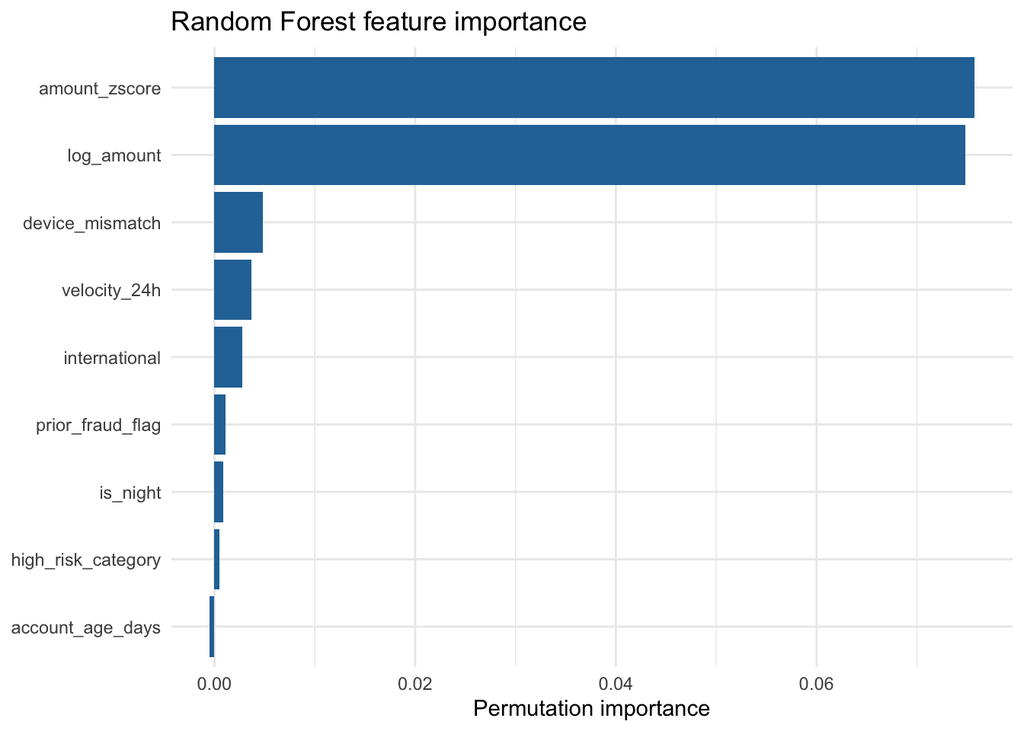

```r
importance |>
  slice_max(permutation_importance, n = 12) |>
  ggplot(aes(x = reorder(feature, permutation_importance),
             y = permutation_importance)) +
  geom_col(fill = "#2874a6") +
  coord_flip() +
  labs(x = NULL, y = "Permutation importance",
       title = "Random Forest feature importance") +
  theme_minimal()
```

Permutation importance describes how predictive performance changes when a feature is permuted in this fitted model. It does not establish causality.

## Anomaly detection and alert-policy trade-offs

The table below compares validation-threshold policies on the held-out test partition.

```r
policy_metrics |>
  filter(split == "test") |>
  select(strategy, target_validation_alert_rate, alerts,
         true_positives, false_positives, false_negatives,
         precision, recall, specificity) |>
  kable(digits = 3, caption = "Anomaly and combined alert policies on test data")
```

Anomaly and combined alert policies on test data

| strategy | target_validation_alert_rate | alerts | true_positives | false_positives | false_negatives | precision | recall | specificity |
| --- | --- | --- | --- | --- | --- | --- | --- | --- |
| Isolation_Forest_top_1pct | 0.01 | 20 | 7 | 13 | 133 | 0.350 | 0.050 | 0.993 |
| XGBoost | 0.01 | 491 | 79 | 412 | 61 | 0.161 | 0.564 | 0.778 |
| XGBoost_OR_IF_top_1pct | 0.01 | 493 | 79 | 414 | 61 | 0.160 | 0.564 | 0.777 |
| XGBoost_AND_IF_top_1pct | 0.01 | 18 | 7 | 11 | 133 | 0.389 | 0.050 | 0.994 |
| Isolation_Forest_top_2pct | 0.02 | 34 | 9 | 25 | 131 | 0.265 | 0.064 | 0.987 |
| XGBoost | 0.02 | 491 | 79 | 412 | 61 | 0.161 | 0.564 | 0.778 |
| XGBoost_OR_IF_top_2pct | 0.02 | 498 | 79 | 419 | 61 | 0.159 | 0.564 | 0.775 |
| XGBoost_AND_IF_top_2pct | 0.02 | 27 | 9 | 18 | 131 | 0.333 | 0.064 | 0.990 |
| Isolation_Forest_top_5pct | 0.05 | 95 | 23 | 72 | 117 | 0.242 | 0.164 | 0.961 |
| XGBoost | 0.05 | 491 | 79 | 412 | 61 | 0.161 | 0.564 | 0.778 |
| XGBoost_OR_IF_top_5pct | 0.05 | 531 | 83 | 448 | 57 | 0.156 | 0.593 | 0.759 |
| XGBoost_AND_IF_top_5pct | 0.05 | 55 | 19 | 36 | 121 | 0.345 | 0.136 | 0.981 |
| Isolation_Forest_top_10pct | 0.10 | 184 | 33 | 151 | 107 | 0.179 | 0.236 | 0.919 |
| XGBoost | 0.10 | 491 | 79 | 412 | 61 | 0.161 | 0.564 | 0.778 |
| XGBoost_OR_IF_top_10pct | 0.10 | 567 | 84 | 483 | 56 | 0.148 | 0.600 | 0.740 |
| XGBoost_AND_IF_top_10pct | 0.10 | 108 | 28 | 80 | 112 | 0.259 | 0.200 | 0.957 |

The OR policy can increase fraud recall by adding anomaly alerts to XGBoost alerts, but it also increases investigation volume and false positives. The AND policy is more restrictive and generally trades recall for precision. A validation target rate does not guarantee the same alert rate on the test set.

## Cost-sensitive investigation scenarios

### Assumptions

```r
assumptions |> kable(caption = "Illustrative financial assumptions")
```

Illustrative financial assumptions

| assumption | value |
| --- | --- |
| cost_per_alert_review | 25 |
| loss_severity | 1 |
| recovery_share_when_detected | 0.8 |
| transaction_amount_interpretation | Transaction amount is a proxy for exposure, not observed realized loss. |

Transaction amount is used as a proxy for fraud exposure. Missed-fraud exposure and the unrecovered share of detected-fraud exposure are scenario calculations. They are not observed realized losses or verified recoveries.

### Policy comparison

```r
feasible_cost_comparison |>
  arrange(estimated_total_cost) |>
  select(strategy, alerts, true_positives, false_positives,
         false_negatives, total_alert_review_cost,
         estimated_missed_fraud_loss, estimated_total_cost) |>
  kable(digits = 2, caption = "Estimated costs under default assumptions")
```

Estimated costs under default assumptions

| strategy | alerts | true_positives | false_positives | false_negatives | total_alert_review_cost | estimated_missed_fraud_loss | estimated_total_cost |
| --- | --- | --- | --- | --- | --- | --- | --- |
| XGBoost | 491 | 79 | 412 | 61 | 12275 | 16318.52 | 28593.52 |
| XGBoost_OR_IF_top_1pct | 493 | 79 | 414 | 61 | 12325 | 16318.52 | 28643.52 |
| XGBoost_OR_IF_top_2pct | 498 | 79 | 419 | 61 | 12450 | 16318.52 | 28768.52 |
| XGBoost_AND_IF_top_10pct | 108 | 28 | 80 | 112 | 2700 | 28558.95 | 31258.95 |
| Isolation_Forest_top_10pct | 184 | 33 | 151 | 107 | 4600 | 27725.93 | 32325.93 |
| XGBoost_AND_IF_top_5pct | 55 | 19 | 36 | 121 | 1375 | 31030.36 | 32405.36 |
| Isolation_Forest_top_5pct | 95 | 23 | 72 | 117 | 2375 | 30282.43 | 32657.43 |
| XGBoost_AND_IF_top_2pct | 27 | 9 | 18 | 131 | 675 | 34407.48 | 35082.48 |
| XGBoost_AND_IF_top_1pct | 18 | 7 | 11 | 133 | 450 | 34673.60 | 35123.60 |
| Isolation_Forest_top_1pct | 20 | 7 | 13 | 133 | 500 | 34673.60 | 35173.60 |
| Isolation_Forest_top_2pct | 34 | 9 | 25 | 131 | 850 | 34407.48 | 35257.48 |

### Sensitivity analysis

```r
feasible_cost_sensitivity |>
  group_by(review_cost_per_alert, recovery_share_when_detected) |>
  slice_min(estimated_total_cost, n = 1, with_ties = FALSE) |>
  ungroup() |>
  select(review_cost_per_alert, recovery_share_when_detected,
         strategy, alerts, estimated_total_cost) |>
  arrange(review_cost_per_alert, recovery_share_when_detected) |>
  kable(digits = 2, caption = "Lowest estimated-cost policy by scenario")
```

Lowest estimated-cost policy by scenario

| review_cost_per_alert | recovery_share_when_detected | strategy | alerts | estimated_total_cost |
| --- | --- | --- | --- | --- |
| 5 | 0.50 | XGBoost | 491 | 26436.88 |
| 5 | 0.80 | XGBoost | 491 | 18773.52 |
| 5 | 0.95 | XGBoost | 491 | 14941.85 |
| 25 | 0.50 | XGBoost_AND_IF_top_10pct | 108 | 34332.14 |
| 25 | 0.80 | XGBoost | 491 | 28593.52 |
| 25 | 0.95 | XGBoost | 491 | 24761.85 |
| 50 | 0.50 | XGBoost_AND_IF_top_5pct | 55 | 35926.78 |
| 50 | 0.80 | XGBoost_AND_IF_top_5pct | 55 | 33780.36 |
| 50 | 0.95 | XGBoost_AND_IF_top_10pct | 108 | 32422.35 |
| 100 | 0.50 | XGBoost_AND_IF_top_1pct | 18 | 37253.80 |
| 100 | 0.80 | XGBoost_AND_IF_top_1pct | 18 | 36473.60 |
| 100 | 0.95 | XGBoost_AND_IF_top_5pct | 55 | 35457.16 |

For this report, the feasible-policy comparison uses a default investigation capacity of 500 alerts. Policies above that limit are excluded from the cost comparison and sensitivity ranking. The Shiny dashboard exposes this capacity as an editable control. Cost rankings are conditional on the assumed review cost, loss severity, recovery share, and available investigation capacity.

## Limitations

- The dataset is simulated and may not reflect real fraud prevalence, feature distributions, adversarial behavior, or operational workflows.
- A single held-out split provides uncertain estimates. Temporal validation and independent external data would be needed for stronger evidence.
- Synthetic feature relationships do not establish causal fraud drivers.
- Transaction amount is only an exposure proxy. Institution-specific loss, recovery, and investigation-cost data are needed for credible financial estimates.
- The dashboard is an analytical demonstration, not a real-time scoring service or case-management system.
- No production monitoring, model drift controls, or deployment architecture is implemented.

## Interactive dashboard

After generating the corrected outputs, launch the dashboard from the repository root:

```r
shiny::runApp("shiny/")
```

The dashboard provides an executive overview, fraud patterns, supervised model comparison, anomaly-policy comparison, cost-sensitive financial analysis, and a held-out transaction explorer.